# ReCell

#### **Price variation for devices across years**

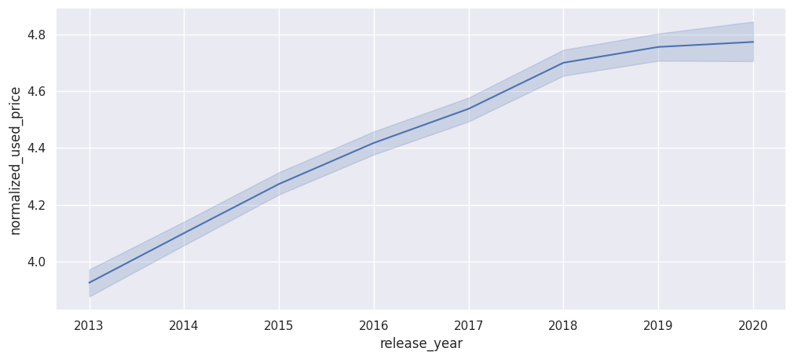

```python
plt.figure(figsize=(12, 5))
sns.lineplot(df, x='release_year', y='normalized_used_price')
plt.show()
```

**Observations:**

- There's a positive relation between release year and the price for a used device. With newer devices the price increases.

#### **Prices variation among 4G and 5G**

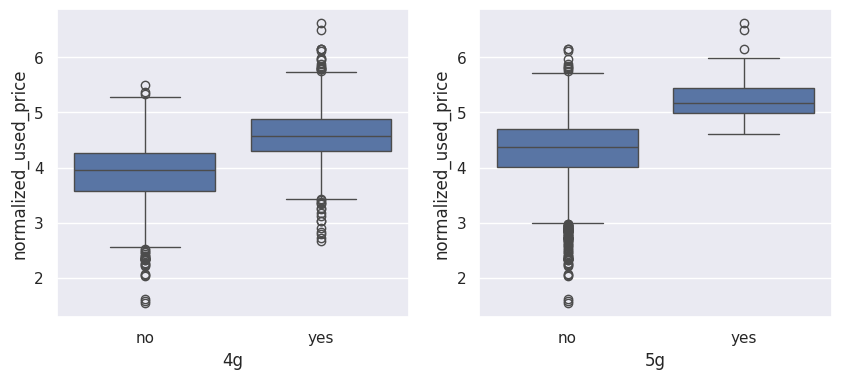

```python
plt.figure(figsize=(10, 4))

plt.subplot(121)
sns.boxplot(data=df, x="4g", y="normalized_used_price")

plt.subplot(122)
sns.boxplot(data=df, x="5g", y="normalized_used_price")

plt.show()
```

**Observations:**

- Devices with 4g enabled have higher normalized price than those without this feature.
- Devices with 5g enabled have higher normalized price than those without this feature.
- Devices that have 5g enabled have higher normalized price than those that have only 4g available.

## Data Preprocessing

- Missing value treatment
- Feature engineering (if needed)
- Outlier detection and treatment (if needed)
- Preparing data for modeling
- Any other preprocessing steps (if needed)

### Missing values treatment

Missing values will be imputed using medians for release_year and brand_name

```python
df.isnull().sum()
```

|  | 0 |
| --- | --- |
| brand_name | 0 |
| os | 0 |
| screen_size | 0 |
| 4g | 0 |
| 5g | 0 |
| main_camera_mp | 179 |
| selfie_camera_mp | 2 |
| int_memory | 4 |
| ram | 4 |
| battery | 6 |
| weight | 7 |
| release_year | 0 |
| days_used | 0 |
| normalized_used_price | 0 |
| normalized_new_price | 0 |

**dtype:** int64

```python
#Making a copy of the Dataset
df_all = df.copy()
```

```python
#Columns that we need to impute
cols_impute = [
    "main_camera_mp",
    "selfie_camera_mp",
    "int_memory",
    "ram",
    "battery",
    "weight",
]
```

```python
#Loop over columns to fill with median
for col in cols_impute:
    df_all[col] = df_all[col].fillna(
        value=df_all.groupby(["release_year", "brand_name"])[col].transform("median")
    )
```

```python
#New check to find null
df_all.isnull().sum()
```

|  | 0 |
| --- | --- |
| brand_name | 0 |
| os | 0 |
| screen_size | 0 |
| 4g | 0 |
| 5g | 0 |
| main_camera_mp | 179 |
| selfie_camera_mp | 2 |
| int_memory | 0 |
| ram | 0 |
| battery | 6 |
| weight | 7 |
| release_year | 0 |
| days_used | 0 |
| normalized_used_price | 0 |
| normalized_new_price | 0 |

**dtype:** int64

Remaining values to be imputed would be using only brand_name

```python
cols_impute = [
    "main_camera_mp",
    "selfie_camera_mp",
    "battery",
    "weight",
]
```

```python
#Loop over columns to fill with median
for col in cols_impute:
    df_all[col] = df_all[col].fillna(
        value=df_all.groupby(["brand_name"])[col].transform("median")
    )
```

```python
#New check to find null
df_all.isnull().sum()
```

|  | 0 |
| --- | --- |
| brand_name | 0 |
| os | 0 |
| screen_size | 0 |
| 4g | 0 |
| 5g | 0 |
| main_camera_mp | 10 |
| selfie_camera_mp | 0 |
| int_memory | 0 |
| ram | 0 |
| battery | 0 |
| weight | 0 |
| release_year | 0 |
| days_used | 0 |
| normalized_used_price | 0 |
| normalized_new_price | 0 |

**dtype:** int64

Finally, filling out main camera mp using median from the column

```python
df_all["main_camera_mp"] = df_all["main_camera_mp"].fillna(df_all["main_camera_mp"].median())
```

```python
# Final check looking for empty values
df_all.isnull().sum()
```

|  | 0 |
| --- | --- |
| brand_name | 0 |
| os | 0 |
| screen_size | 0 |
| 4g | 0 |
| 5g | 0 |
| main_camera_mp | 0 |
| selfie_camera_mp | 0 |
| int_memory | 0 |
| ram | 0 |
| battery | 0 |
| weight | 0 |
| release_year | 0 |
| days_used | 0 |
| normalized_used_price | 0 |
| normalized_new_price | 0 |

**dtype:** int64

### Feature engineering

**Procedure:**

- We need to identified the total of years that a used device has been in service and determine if this feature influence possible buyers' decision.

```python
df_all["years_since_release"] = 2021 - df_all["release_year"]
df_all.drop("release_year", axis=1, inplace=True)
df_all["years_since_release"].describe()
```

|  | years_since_release |
| --- | --- |
| count | 3454.000000 |
| mean | 5.034742 |
| std | 2.298455 |
| min | 1.000000 |
| 25% | 3.000000 |
| 50% | 5.500000 |
| 75% | 7.000000 |
| max | 8.000000 |

**dtype:** float64

### Outlier detection and treatment

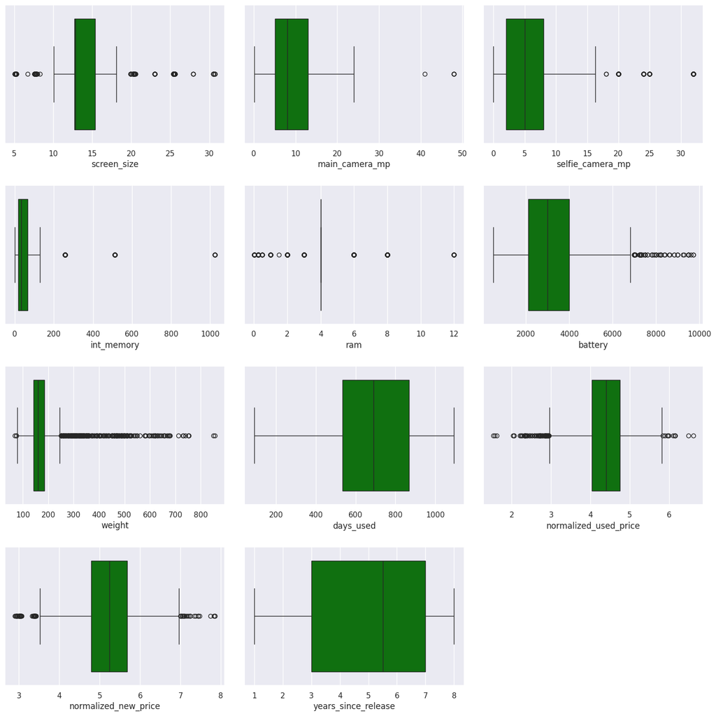

```python
# outlier detection using boxplot
num_cols = df_all.select_dtypes(include=np.number).columns.tolist()

plt.figure(figsize=(15, 15))

for i, variable in enumerate(num_cols):
    plt.subplot(4, 3, i + 1)
    sns.boxplot(df_all, x=variable, color='green')
    plt.tight_layout(pad=2)

plt.show()
```

**Observations:**

- There are quite a few outliers in the data
- However, we will not treat them as they are proper values

### Preparing data for modeling

#### **`Process to follow`**

- Predict the normalized price of used devices using a model
- Define dependent and independent variables
- Add interception to data (constant)
- Encode categorical features (Create dummies)
- Divide data in 2 datasets: Training(70% of data) and testing(30% of data)
- We will build a Linear Regression model using the train data and then check it's performance

```python
## Complete the code to define the dependent and independent variables
X = df_all.drop(['normalized_used_price'], axis=1)
y = df_all['normalized_used_price']
```

```python
print(X.head())
```

```
  brand_name       os  screen_size   4g   5g  main_camera_mp  \
0      Honor  Android        14.50  yes   no            13.0
1      Honor  Android        17.30  yes  yes            13.0
2      Honor  Android        16.69  yes  yes            13.0
3      Honor  Android        25.50  yes  yes            13.0
4      Honor  Android        15.32  yes   no            13.0

   selfie_camera_mp  int_memory  ram  battery  weight  days_used  \
0               5.0        64.0  3.0   3020.0   146.0        127
1              16.0       128.0  8.0   4300.0   213.0        325
2               8.0       128.0  8.0   4200.0   213.0        162
3               8.0        64.0  6.0   7250.0   480.0        345
4               8.0        64.0  3.0   5000.0   185.0        293

   normalized_new_price  years_since_release
0              4.715100                    1
1              5.519018                    1
2              5.884631                    1
3              5.630961                    1
4              4.947837                    1
```

```python
print(y.head())
```

```
0    4.307572
1    5.162097
2    5.111084
3    5.135387
4    4.389995
Name: normalized_used_price, dtype: float64
```

**`adding intercept of data`**

```python
X = sm.add_constant(X)
```

**`creating and threating dummies`**

```python
X = pd.get_dummies(
    X,
    columns=X.select_dtypes(include=["object", "category"]).columns.tolist(),
    drop_first=True,
)
#transforming booleans into floats (1, 0)
X = X.astype(float)

X.head()
```

|  | const | screen_size | main_camera_mp | selfie_camera_mp | int_memory | ram | battery | weight | days_used | normalized_new_price | ... | brand_name_Spice | brand_name_Vivo | brand_name_XOLO | brand_name_Xiaomi | brand_name_ZTE | os_Others | os_Windows | os_iOS | 4g_yes | 5g_yes |
| --- | --- | --- | --- | --- | --- | --- | --- | --- | --- | --- | --- | --- | --- | --- | --- | --- | --- | --- | --- | --- | --- |
| 0 | 1.0 | 14.50 | 13.0 | 5.0 | 64.0 | 3.0 | 3020.0 | 146.0 | 127.0 | 4.715100 | ... | 0.0 | 0.0 | 0.0 | 0.0 | 0.0 | 0.0 | 0.0 | 0.0 | 1.0 | 0.0 |
| 1 | 1.0 | 17.30 | 13.0 | 16.0 | 128.0 | 8.0 | 4300.0 | 213.0 | 325.0 | 5.519018 | ... | 0.0 | 0.0 | 0.0 | 0.0 | 0.0 | 0.0 | 0.0 | 0.0 | 1.0 | 1.0 |
| 2 | 1.0 | 16.69 | 13.0 | 8.0 | 128.0 | 8.0 | 4200.0 | 213.0 | 162.0 | 5.884631 | ... | 0.0 | 0.0 | 0.0 | 0.0 | 0.0 | 0.0 | 0.0 | 0.0 | 1.0 | 1.0 |
| 3 | 1.0 | 25.50 | 13.0 | 8.0 | 64.0 | 6.0 | 7250.0 | 480.0 | 345.0 | 5.630961 | ... | 0.0 | 0.0 | 0.0 | 0.0 | 0.0 | 0.0 | 0.0 | 0.0 | 1.0 | 1.0 |
| 4 | 1.0 | 15.32 | 13.0 | 8.0 | 64.0 | 3.0 | 5000.0 | 185.0 | 293.0 | 4.947837 | ... | 0.0 | 0.0 | 0.0 | 0.0 | 0.0 | 0.0 | 0.0 | 0.0 | 1.0 | 0.0 |

5 rows × 49 columns

**`creating test and training data`**

```python
x_train, x_test, y_train, y_test = train_test_split(X, y, test_size=0.3, random_state=1)
print("Number of rows in train data =", x_train.shape[0])
print("Number of rows in test data =", x_test.shape[0])
```

```
Number of rows in train data = 2417
Number of rows in test data = 1037
```

## Model Building - Linear Regression

Creating the first model

```python
olsmodel1 = sm.OLS(y_train, x_train).fit() ## Complete the code to fit OLS model
print(olsmodel1.summary())
```

```
                              OLS Regression Results
=================================================================================
Dep. Variable:     normalized_used_price   R-squared:                       0.845
Model:                               OLS   Adj. R-squared:                  0.842
Method:                    Least Squares   F-statistic:                     268.7
Date:                   Fri, 11 Oct 2024   Prob (F-statistic):               0.00
Time:                           20:29:34   Log-Likelihood:                 123.85
No. Observations:                   2417   AIC:                            -149.7
Df Residuals:                       2368   BIC:                             134.0
Df Model:                             48
Covariance Type:               nonrobust
=========================================================================================
                            coef    std err          t      P>|t|      [0.025      0.975]
-----------------------------------------------------------------------------------------
const                     1.3156      0.071     18.454      0.000       1.176       1.455
screen_size               0.0244      0.003      7.163      0.000       0.018       0.031
main_camera_mp            0.0208      0.002     13.848      0.000       0.018       0.024
selfie_camera_mp          0.0135      0.001     11.997      0.000       0.011       0.016
int_memory                0.0001   6.97e-05      1.651      0.099   -2.16e-05       0.000
ram                       0.0230      0.005      4.451      0.000       0.013       0.033
battery               -1.689e-05   7.27e-06     -2.321      0.020   -3.12e-05   -2.62e-06
weight                    0.0010      0.000      7.480      0.000       0.001       0.001
days_used              4.216e-05   3.09e-05      1.366      0.172   -1.84e-05       0.000
normalized_new_price      0.4311      0.012     35.147      0.000       0.407       0.455
years_since_release      -0.0237      0.005     -5.193      0.000      -0.033      -0.015
brand_name_Alcatel        0.0154      0.048      0.323      0.747      -0.078       0.109
brand_name_Apple         -0.0038      0.147     -0.026      0.980      -0.292       0.285
brand_name_Asus           0.0151      0.048      0.314      0.753      -0.079       0.109
brand_name_BlackBerry    -0.0300      0.070     -0.427      0.669      -0.168       0.108
brand_name_Celkon        -0.0468      0.066     -0.707      0.480      -0.177       0.083
brand_name_Coolpad        0.0209      0.073      0.287      0.774      -0.122       0.164
brand_name_Gionee         0.0448      0.058      0.775      0.438      -0.068       0.158
brand_name_Google        -0.0326      0.085     -0.385      0.700      -0.199       0.133
brand_name_HTC           -0.0130      0.048     -0.270      0.787      -0.108       0.081
brand_name_Honor          0.0317      0.049      0.644      0.520      -0.065       0.128
brand_name_Huawei        -0.0020      0.044     -0.046      0.964      -0.089       0.085
brand_name_Infinix        0.1633      0.093      1.752      0.080      -0.019       0.346
brand_name_Karbonn        0.0943      0.067      1.405      0.160      -0.037       0.226
brand_name_LG            -0.0132      0.045     -0.291      0.771      -0.102       0.076
brand_name_Lava           0.0332      0.062      0.533      0.594      -0.089       0.155
```

[output cut: 19 more lines]

```
os_Windows               -0.0207      0.045     -0.459      0.646      -0.109       0.068
os_iOS                   -0.0663      0.146     -0.453      0.651      -0.354       0.221
4g_yes                    0.0528      0.016      3.326      0.001       0.022       0.084
5g_yes                   -0.0714      0.031     -2.268      0.023      -0.133      -0.010
==============================================================================
Omnibus:                      223.612   Durbin-Watson:                   1.910
Prob(Omnibus):                  0.000   Jarque-Bera (JB):              422.275
Skew:                          -0.620   Prob(JB):                     2.01e-92
Kurtosis:                       4.630   Cond. No.                     1.78e+05
==============================================================================

Notes:
[1] Standard Errors assume that the covariance matrix of the errors is correctly specified.
[2] The condition number is large, 1.78e+05. This might indicate that there are
strong multicollinearity or other numerical problems.
```

**Observations**

- Adjusted. R-squared: Our model can explain **84.2**% of the variance in the training set.
- Const coefficient: It is the Y-intercept. If all the predictor variable coefficients are zero, then the expected output would be **1.3156**
- Coefficient of a predictor variable: It represents the change in the output Y due to a change in the predictor variable (everything else held constant). In our case the value of normalized_new_price is **0.4311**

## Model Performance Check

**`Checks to be done:`**

- We will be using metric functions defined in sklearn for RMSE, MAE, and $R^2$.
- We will define a function to calculate MAPE and adjusted $R^2$.
- A function will be used to print the values created in the first 2 steps so we can visually understand the results.

**`Function to work with adjusted R-squared`**

```python
def adj_r2_score(predictors, targets, predictions):
    r2 = r2_score(targets, predictions)
    n = predictors.shape[0]
    k = predictors.shape[1]
    return 1 - ((1 - r2) * (n - 1) / (n - k - 1))


# function to compute MAPE
def mape_score(targets, predictions):
    return np.mean(np.abs(targets - predictions) / targets) * 100


# function to compute different metrics to check performance of a regression model
def model_performance_regression(model, predictors, target):
    """
    Function to compute different metrics to check regression model performance

    model: regressor
    predictors: independent variables
    target: dependent variable
    """

    # predicting using the independent variables
    pred = model.predict(predictors)

    r2 = r2_score(target, pred)  # to compute R-squared
    adjr2 = adj_r2_score(predictors, target, pred)  # to compute adjusted R-squared
    rmse = np.sqrt(mean_squared_error(target, pred))  # to compute RMSE
    mae = mean_absolute_error(target, pred)  # to compute MAE
    mape = mape_score(target, pred)  # to compute MAPE

    # creating a dataframe of metrics
    df_perf = pd.DataFrame(
        {
            "RMSE": rmse,
            "MAE": mae,
            "R-squared": r2,
            "Adj. R-squared": adjr2,
            "MAPE": mape,
        },
        index=[0],
    )

    return df_perf
```

```python
# checking model performance on train set (seen 70% data)
print("Training Performance\n")
olsmodel1_train_perf = model_performance_regression(olsmodel1, x_train, y_train)
olsmodel1_train_perf
```

```
Training Performance
```

|  | RMSE | MAE | R-squared | Adj. R-squared | MAPE |
| --- | --- | --- | --- | --- | --- |
| 0 | 0.229884 | 0.180326 | 0.844886 | 0.841675 | 4.326841 |

**Observations**

## Checking Linear Regression Assumptions

In order to make statistical inferences from a linear regression model, it is important to ensure that the assumptions of linear regression are satisfied.

1. **No Multicollinearity**
2. **Linearity of variables and independence**
3. **Normality of error terms**
4. **No Heteroscedasticity**

#### TEST FOR MULTICOLLINEARITY

- We will test for multicollinearity using VIF.
- **General Rule of thumb**:
  - If VIF is 1 then there is no correlation between the $k$th predictor and the remaining predictor variables.
  - If VIF exceeds 5 or is close to exceeding 5, we say there is moderate multicollinearity.
  - If VIF is 10 or exceeding 10, it shows signs of high multicollinearity.

```python
#FUNCTION to check VIF
def checking_vif(predictors):
    vif = pd.DataFrame()
    vif["feature"] = predictors.columns
    # calculating VIF for each feature
    vif["VIF"] = [
        variance_inflation_factor(predictors.values, i)
        for i in range(len(predictors.columns))
    ]
    return vif
```

```python
# Initial check of data used for training
checking_vif(x_train)
```

|  | feature | VIF |
| --- | --- | --- |
| 0 | const | 227.744081 |
| 1 | screen_size | 7.677290 |
| 2 | main_camera_mp | 2.285051 |
| 3 | selfie_camera_mp | 2.812473 |
| 4 | int_memory | 1.364152 |
| 5 | ram | 2.282352 |
| 6 | battery | 4.081780 |
| 7 | weight | 6.396749 |
| 8 | days_used | 2.660269 |
| 9 | normalized_new_price | 3.119430 |
| 10 | years_since_release | 4.899007 |
| 11 | brand_name_Alcatel | 3.405693 |
| 12 | brand_name_Apple | 13.057668 |
| 13 | brand_name_Asus | 3.332038 |
| 14 | brand_name_BlackBerry | 1.632378 |
| 15 | brand_name_Celkon | 1.774721 |
| 16 | brand_name_Coolpad | 1.468006 |
| 17 | brand_name_Gionee | 1.951272 |
| 18 | brand_name_Google | 1.321778 |
| 19 | brand_name_HTC | 3.410361 |
| 20 | brand_name_Honor | 3.340687 |
| 21 | brand_name_Huawei | 5.983852 |
| 22 | brand_name_Infinix | 1.283955 |
| 23 | brand_name_Karbonn | 1.573702 |
| 24 | brand_name_LG | 4.849832 |
| 25 | brand_name_Lava | 1.711360 |
| 26 | brand_name_Lenovo | 4.558941 |
| 27 | brand_name_Meizu | 2.179607 |
| 28 | brand_name_Micromax | 3.363521 |
| 29 | brand_name_Microsoft | 1.869751 |
| 30 | brand_name_Motorola | 3.274558 |
| 31 | brand_name_Nokia | 3.479849 |
| 32 | brand_name_OnePlus | 1.437034 |
| 33 | brand_name_Oppo | 3.971194 |
| 34 | brand_name_Others | 9.711034 |
| 35 | brand_name_Panasonic | 2.105703 |
| 36 | brand_name_Realme | 1.946812 |
| 37 | brand_name_Samsung | 7.539866 |
| 38 | brand_name_Sony | 2.943161 |
| 39 | brand_name_Spice | 1.688863 |
| 40 | brand_name_Vivo | 3.651437 |
| 41 | brand_name_XOLO | 2.138070 |
| 42 | brand_name_Xiaomi | 3.719689 |
| 43 | brand_name_ZTE | 3.797581 |
| 44 | os_Others | 1.859863 |
| 45 | os_Windows | 1.596034 |
| 46 | os_iOS | 11.784684 |
| 47 | 4g_yes | 2.467681 |
| 48 | 5g_yes | 1.813900 |

##### **`Removing Multicollinearity`**

To remove MC we follow the steps learned in class:

1. Drop every column one by one that has a VIF score close to or greater than 5.
2. Look at the adjusted R-squared and RMSE of all these models.
3. Drop the variable that makes the least change in adjusted R-squared.
4. Check the VIF scores again.
5. Continue till you get all VIF scores under 5.

A function is created to keep checing MC as we drop columns and check VIF.

```python
def treating_multicollinearity(predictors, target, high_vif_columns):
    """
    Checking the effect of dropping the columns showing high multicollinearity
    on model performance (adj. R-squared and RMSE)

    predictors: independent variables
    target: dependent variable
    high_vif_columns: columns having high VIF
    """
    # empty lists to store adj. R-squared and RMSE values
    adj_r2 = []
    rmse = []

    # build ols models by dropping one of the high VIF columns at a time
    # store the adjusted R-squared and RMSE in the lists defined previously
    for cols in high_vif_columns:
        # defining the new train set
        train = predictors.loc[:, ~predictors.columns.str.startswith(cols)]

        # create the model
        olsmodel = sm.OLS(target, train).fit()

        # adding adj. R-squared and RMSE to the lists
        adj_r2.append(olsmodel.rsquared_adj)
        rmse.append(np.sqrt(olsmodel.mse_resid))

    # creating a dataframe for the results
    temp = pd.DataFrame(
        {
            "col": high_vif_columns,
            "Adj. R-squared after_dropping col": adj_r2,
            "RMSE after dropping col": rmse,
        }
    ).sort_values(by="Adj. R-squared after_dropping col", ascending=False)
    temp.reset_index(drop=True, inplace=True)

    return temp
```

```python
# Initial set of columns found in the fist check for MC:
col_list = ['screen_size',
            'weight',
            'years_since_release',
            'brand_name_Apple',
            'brand_name_Huawei',
            'brand_name_LG',
            'brand_name_Others',
            'brand_name_Samsung',
            'os_iOS']

#Call to evaluate MC for each of these columns
res = treating_multicollinearity(x_train, y_train, col_list)
res
```

|  | col | Adj. R-squared after_dropping col | RMSE after dropping col |
| --- | --- | --- | --- |
| 0 | brand_name_Apple | 0.841809 | 0.232201 |
| 1 | brand_name_Huawei | 0.841808 | 0.232201 |
| 2 | brand_name_Others | 0.841806 | 0.232203 |
| 3 | brand_name_LG | 0.841803 | 0.232205 |
| 4 | os_iOS | 0.841795 | 0.232211 |
| 5 | brand_name_Samsung | 0.841774 | 0.232227 |
| 6 | years_since_release | 0.840007 | 0.233519 |
| 7 | screen_size | 0.838381 | 0.234703 |
| 8 | weight | 0.838071 | 0.234928 |

###### Dropping **brand_name_Apple** and re-evaluating

```python
col_to_drop = 'brand_name_Apple'
#After each elimination a new DS is created to avoid overwriting.
x_train2 = x_train.loc[:, ~x_train.columns.str.startswith(col_to_drop)]
x_test2 = x_test.loc[:, ~x_test.columns.str.startswith(col_to_drop)]

# Check VIF now
vif = checking_vif(x_train2)
print("VIF after dropping ", col_to_drop)
vif
```

```
VIF after dropping  brand_name_Apple
```

|  | feature | VIF |
| --- | --- | --- |
| 0 | const | 227.303871 |
| 1 | screen_size | 7.643583 |
| 2 | main_camera_mp | 2.284429 |
| 3 | selfie_camera_mp | 2.791121 |
| 4 | int_memory | 1.364138 |
| 5 | ram | 2.273686 |
| 6 | battery | 4.079720 |
| 7 | weight | 6.394014 |
| 8 | days_used | 2.659799 |
| 9 | normalized_new_price | 3.102417 |
| 10 | years_since_release | 4.890322 |
| 11 | brand_name_Alcatel | 3.230773 |
| 12 | brand_name_Asus | 3.145077 |
| 13 | brand_name_BlackBerry | 1.561121 |
| 14 | brand_name_Celkon | 1.731854 |
| 15 | brand_name_Coolpad | 1.436852 |
| 16 | brand_name_Gionee | 1.886381 |
| 17 | brand_name_Google | 1.293163 |
| 18 | brand_name_HTC | 3.240658 |
| 19 | brand_name_Honor | 3.160024 |
| 20 | brand_name_Huawei | 5.581714 |
| 21 | brand_name_Infinix | 1.265587 |
| 22 | brand_name_Karbonn | 1.544264 |
| 23 | brand_name_LG | 4.565534 |
| 24 | brand_name_Lava | 1.670810 |
| 25 | brand_name_Lenovo | 4.291839 |
| 26 | brand_name_Meizu | 2.092837 |
| 27 | brand_name_Micromax | 3.214171 |
| 28 | brand_name_Microsoft | 1.835669 |
| 29 | brand_name_Motorola | 3.109867 |
| 30 | brand_name_Nokia | 3.266268 |
| 31 | brand_name_OnePlus | 1.402445 |
| 32 | brand_name_Oppo | 3.762937 |
| 33 | brand_name_Others | 9.075554 |
| 34 | brand_name_Panasonic | 2.030895 |
| 35 | brand_name_Realme | 1.878915 |
| 36 | brand_name_Samsung | 6.991538 |
| 37 | brand_name_Sony | 2.799174 |
| 38 | brand_name_Spice | 1.655389 |
| 39 | brand_name_Vivo | 3.447853 |
| 40 | brand_name_XOLO | 2.069729 |
| 41 | brand_name_Xiaomi | 3.513125 |
| 42 | brand_name_ZTE | 3.604439 |
| 43 | os_Others | 1.739572 |
| 44 | os_Windows | 1.593814 |
| 45 | os_iOS | 1.908608 |
| 46 | 4g_yes | 2.466689 |
| 47 | 5g_yes | 1.805259 |

```python
# New evaluation of the model without column removed:
col_list = ['screen_size',
            'weight',
            'years_since_release',
            'brand_name_Huawei',
            'brand_name_LG',
            'brand_name_Others',
            'brand_name_Samsung']
#Call to evaluate MC for each of these columns
res = treating_multicollinearity(x_train, y_train, col_list)
res
```

|  | col | Adj. R-squared after_dropping col | RMSE after dropping col |
| --- | --- | --- | --- |
| 0 | brand_name_Huawei | 0.841808 | 0.232201 |
| 1 | brand_name_Others | 0.841806 | 0.232203 |
| 2 | brand_name_LG | 0.841803 | 0.232205 |
| 3 | brand_name_Samsung | 0.841774 | 0.232227 |
| 4 | years_since_release | 0.840007 | 0.233519 |
| 5 | screen_size | 0.838381 | 0.234703 |
| 6 | weight | 0.838071 | 0.234928 |

###### Dropping **brand_name_Huawei** and re-evaluating

```python
#After each elimination a new DS is created to avoid overwriting.
col_to_drop = 'brand_name_Huawei'
x_train3 = x_train2.loc[:, ~x_train2.columns.str.startswith(col_to_drop)]
x_test3 = x_test2.loc[:, ~x_test2.columns.str.startswith(col_to_drop)]

# Check VIF now
vif = checking_vif(x_train3)
print("VIF after dropping ", col_to_drop)
vif
```

```
VIF after dropping  brand_name_Huawei
```

|  | feature | VIF |
| --- | --- | --- |
| 0 | const | 168.020551 |
| 1 | screen_size | 7.631172 |
| 2 | main_camera_mp | 2.284069 |
| 3 | selfie_camera_mp | 2.780909 |
| 4 | int_memory | 1.362495 |
| 5 | ram | 2.272754 |
| 6 | battery | 4.079196 |
| 7 | weight | 6.393234 |
| 8 | days_used | 2.659317 |
| 9 | normalized_new_price | 3.102129 |
| 10 | years_since_release | 4.890240 |
| 11 | brand_name_Alcatel | 1.434036 |
| 12 | brand_name_Asus | 1.367355 |
| 13 | brand_name_BlackBerry | 1.158290 |
| 14 | brand_name_Celkon | 1.257428 |
| 15 | brand_name_Coolpad | 1.080731 |
| 16 | brand_name_Gionee | 1.169453 |
| 17 | brand_name_Google | 1.059218 |
| 18 | brand_name_HTC | 1.400717 |
| 19 | brand_name_Honor | 1.356413 |
| 20 | brand_name_Infinix | 1.070724 |
| 21 | brand_name_Karbonn | 1.137121 |
| 22 | brand_name_LG | 1.611822 |
| 23 | brand_name_Lava | 1.145103 |
| 24 | brand_name_Lenovo | 1.563553 |
| 25 | brand_name_Meizu | 1.184730 |
| 26 | brand_name_Micromax | 1.480644 |
| 27 | brand_name_Microsoft | 1.540532 |
| 28 | brand_name_Motorola | 1.381692 |
| 29 | brand_name_Nokia | 1.713629 |
| 30 | brand_name_OnePlus | 1.084228 |
| 31 | brand_name_Oppo | 1.461835 |
| 32 | brand_name_Others | 2.440105 |
| 33 | brand_name_Panasonic | 1.188348 |
| 34 | brand_name_Realme | 1.196286 |
| 35 | brand_name_Samsung | 2.000047 |
| 36 | brand_name_Sony | 1.345151 |
| 37 | brand_name_Spice | 1.163407 |
| 38 | brand_name_Vivo | 1.399676 |
| 39 | brand_name_XOLO | 1.240841 |
| 40 | brand_name_Xiaomi | 1.412073 |
| 41 | brand_name_ZTE | 1.453068 |
| 42 | os_Others | 1.732993 |
| 43 | os_Windows | 1.593605 |
| 44 | os_iOS | 1.224011 |
| 45 | 4g_yes | 2.447008 |
| 46 | 5g_yes | 1.803835 |

```python
# New evaluation of the model without column removed:
col_list = ['screen_size',
            'weight',
            'years_since_release'
            ]
res = treating_multicollinearity(x_train, y_train, col_list)
res
```

|  | col | Adj. R-squared after_dropping col | RMSE after dropping col |
| --- | --- | --- | --- |
| 0 | years_since_release | 0.840007 | 0.233519 |
| 1 | screen_size | 0.838381 | 0.234703 |
| 2 | weight | 0.838071 | 0.234928 |

###### Dropping **years_since_release** and re-evaluating

```python
#After each elimination a new DS is created to avoid overwriting.
col_to_drop = 'years_since_release'
x_train4 = x_train3.loc[:, ~x_train3.columns.str.startswith(col_to_drop)]
x_test4 = x_test3.loc[:, ~x_test3.columns.str.startswith(col_to_drop)]

# Check VIF now
vif = checking_vif(x_train4)
print("VIF after dropping ", col_to_drop)
vif
```

```
VIF after dropping  years_since_release
```

|  | feature | VIF |
| --- | --- | --- |
| 0 | const | 162.699578 |
| 1 | screen_size | 7.358795 |
| 2 | main_camera_mp | 2.272393 |
| 3 | selfie_camera_mp | 2.483454 |
| 4 | int_memory | 1.346347 |
| 5 | ram | 2.271189 |
| 6 | battery | 3.956113 |
| 7 | weight | 6.165888 |
| 8 | days_used | 1.907542 |
| 9 | normalized_new_price | 2.899427 |
| 10 | brand_name_Alcatel | 1.433988 |
| 11 | brand_name_Asus | 1.367082 |
| 12 | brand_name_BlackBerry | 1.156426 |
| 13 | brand_name_Celkon | 1.247699 |
| 14 | brand_name_Coolpad | 1.080418 |
| 15 | brand_name_Gionee | 1.169102 |
| 16 | brand_name_Google | 1.054586 |
| 17 | brand_name_HTC | 1.399615 |
| 18 | brand_name_Honor | 1.356333 |
| 19 | brand_name_Infinix | 1.070382 |
| 20 | brand_name_Karbonn | 1.131710 |
| 21 | brand_name_LG | 1.611809 |
| 22 | brand_name_Lava | 1.144904 |
| 23 | brand_name_Lenovo | 1.561471 |
| 24 | brand_name_Meizu | 1.183916 |
| 25 | brand_name_Micromax | 1.480129 |
| 26 | brand_name_Microsoft | 1.536148 |
| 27 | brand_name_Motorola | 1.381296 |
| 28 | brand_name_Nokia | 1.691546 |
| 29 | brand_name_OnePlus | 1.084209 |
| 30 | brand_name_Oppo | 1.460313 |
| 31 | brand_name_Others | 2.439684 |
| 32 | brand_name_Panasonic | 1.188125 |
| 33 | brand_name_Realme | 1.193376 |
| 34 | brand_name_Samsung | 1.999382 |
| 35 | brand_name_Sony | 1.343304 |
| 36 | brand_name_Spice | 1.160672 |
| 37 | brand_name_Vivo | 1.399561 |
| 38 | brand_name_XOLO | 1.239093 |
| 39 | brand_name_Xiaomi | 1.411976 |
| 40 | brand_name_ZTE | 1.452299 |
| 41 | os_Others | 1.732555 |
| 42 | os_Windows | 1.586400 |
| 43 | os_iOS | 1.219086 |
| 44 | 4g_yes | 2.102178 |
| 45 | 5g_yes | 1.782562 |

```python
# New evaluation of the model without column removed:
col_list = ['screen_size',
            'weight'
            ]

res = treating_multicollinearity(x_train, y_train, col_list)
res
```

|  | col | Adj. R-squared after_dropping col | RMSE after dropping col |
| --- | --- | --- | --- |
| 0 | screen_size | 0.838381 | 0.234703 |
| 1 | weight | 0.838071 | 0.234928 |

###### Dropping **screen_size** and re-evaluating

```python
#After each elimination a new DS is created to avoid overwriting.
col_to_drop = 'screen_size'
x_train5 = x_train4.loc[:, ~x_train4.columns.str.startswith(col_to_drop)]
x_test5 = x_test4.loc[:, ~x_test4.columns.str.startswith(col_to_drop)]

# Check VIF now
vif = checking_vif(x_train5)
print("VIF after dropping ", col_to_drop)
vif
```

```
VIF after dropping  screen_size
```

|  | feature | VIF |
| --- | --- | --- |
| 0 | const | 143.347256 |
| 1 | main_camera_mp | 2.266054 |
| 2 | selfie_camera_mp | 2.460653 |
| 3 | int_memory | 1.345777 |
| 4 | ram | 2.271186 |
| 5 | battery | 3.632634 |
| 6 | weight | 2.969761 |
| 7 | days_used | 1.831285 |
| 8 | normalized_new_price | 2.882086 |
| 9 | brand_name_Alcatel | 1.432521 |
| 10 | brand_name_Asus | 1.364344 |
| 11 | brand_name_BlackBerry | 1.155008 |
| 12 | brand_name_Celkon | 1.247343 |
| 13 | brand_name_Coolpad | 1.080416 |
| 14 | brand_name_Gionee | 1.161469 |
| 15 | brand_name_Google | 1.053747 |
| 16 | brand_name_HTC | 1.392787 |
| 17 | brand_name_Honor | 1.354149 |
| 18 | brand_name_Infinix | 1.070307 |
| 19 | brand_name_Karbonn | 1.131481 |
| 20 | brand_name_LG | 1.601708 |
| 21 | brand_name_Lava | 1.144893 |
| 22 | brand_name_Lenovo | 1.559047 |
| 23 | brand_name_Meizu | 1.182831 |
| 24 | brand_name_Micromax | 1.477835 |
| 25 | brand_name_Microsoft | 1.535855 |
| 26 | brand_name_Motorola | 1.374494 |
| 27 | brand_name_Nokia | 1.685545 |
| 28 | brand_name_OnePlus | 1.084175 |
| 29 | brand_name_Oppo | 1.457448 |
| 30 | brand_name_Others | 2.403133 |
| 31 | brand_name_Panasonic | 1.188066 |
| 32 | brand_name_Realme | 1.192537 |
| 33 | brand_name_Samsung | 1.990488 |
| 34 | brand_name_Sony | 1.339446 |
| 35 | brand_name_Spice | 1.155799 |
| 36 | brand_name_Vivo | 1.399552 |
| 37 | brand_name_XOLO | 1.239079 |
| 38 | brand_name_Xiaomi | 1.409451 |
| 39 | brand_name_ZTE | 1.447452 |
| 40 | os_Others | 1.517309 |
| 41 | os_Windows | 1.586387 |
| 42 | os_iOS | 1.213910 |
| 43 | 4g_yes | 2.095604 |
| 44 | 5g_yes | 1.780867 |

**Output:** The listed predictors have little to no multicollinearity and **the assumption is satisfied**.

##### **Removing columns wiht high p-value**

Following the learning in classs the process goes as follows:

- We will drop the predictor variables having a p-value greater than 0.05 as they do not significantly impact the target variable.
- Steps:
  - Build a model, check the p-values of the variables, and drop the column with the highest p-value.
  - Create a new model without the dropped feature, check the p-values of the variables, and drop the column with the highest p-value.
  - Repeat the above two steps till there are no columns with p-value > 0.05.

```python
predictors = x_train5.copy()
cols = predictors.columns.tolist()
# setting an initial max p-value
max_p_value = 1
while len(cols) > 0:
    # defining the train set
    x_train_aux = predictors[cols]

    # fitting the model
    model = sm.OLS(y_train, x_train_aux).fit()

    # getting the p-values and the maximum p-value
    p_values = model.pvalues
    max_p_value = max(p_values)

    # name of the variable with maximum p-value
    feature_with_p_max = p_values.idxmax()

    if max_p_value > 0.05:
        cols.remove(feature_with_p_max)
    else:
        break

selected_features = cols
print(selected_features)
```

```
['const', 'main_camera_mp', 'selfie_camera_mp', 'ram', 'weight', 'days_used', 'normalized_new_price', 'brand_name_Honor', 'brand_name_Infinix', 'brand_name_Lenovo', 'brand_name_Nokia', 'brand_name_Sony', 'brand_name_Xiaomi', 'os_Others', '4g_yes']
```

After obtaining the predictors that are less than 0.05 on their p-value, we can now traing and test a new model.

```python
x_train6 = x_train5[selected_features]
x_test6 = x_test5[selected_features]
```

Generating new model

```python
olsmodel2 = sm.OLS(y_train, x_train6).fit()
print(olsmodel2.summary())
```

```
                              OLS Regression Results
=================================================================================
Dep. Variable:     normalized_used_price   R-squared:                       0.836
Model:                               OLS   Adj. R-squared:                  0.835
Method:                    Least Squares   F-statistic:                     875.6
Date:                   Fri, 11 Oct 2024   Prob (F-statistic):               0.00
Time:                           20:30:29   Log-Likelihood:                 57.707
No. Observations:                   2417   AIC:                            -85.41
Df Residuals:                       2402   BIC:                             1.440
Df Model:                             14
Covariance Type:               nonrobust
========================================================================================
                           coef    std err          t      P>|t|      [0.025      0.975]
----------------------------------------------------------------------------------------
const                    1.4591      0.048     30.413      0.000       1.365       1.553
main_camera_mp           0.0228      0.001     16.045      0.000       0.020       0.026
selfie_camera_mp         0.0170      0.001     16.998      0.000       0.015       0.019
ram                      0.0186      0.005      4.109      0.000       0.010       0.027
weight                   0.0017   6.02e-05     28.436      0.000       0.002       0.002
days_used            -9.318e-05   2.42e-05     -3.849      0.000      -0.000   -4.57e-05
normalized_new_price     0.4180      0.011     39.050      0.000       0.397       0.439
brand_name_Honor         0.0575      0.028      2.052      0.040       0.003       0.112
brand_name_Infinix       0.1830      0.085      2.155      0.031       0.016       0.350
brand_name_Lenovo        0.0503      0.022      2.299      0.022       0.007       0.093
brand_name_Nokia         0.0807      0.031      2.608      0.009       0.020       0.141
brand_name_Sony         -0.0682      0.031     -2.222      0.026      -0.128      -0.008
brand_name_Xiaomi        0.0937      0.026      3.602      0.000       0.043       0.145
os_Others               -0.1577      0.028     -5.548      0.000      -0.213      -0.102
4g_yes                   0.0898      0.014      6.580      0.000       0.063       0.117
==============================================================================
Omnibus:                      226.072   Durbin-Watson:                   1.915
Prob(Omnibus):                  0.000   Jarque-Bera (JB):              416.351
Skew:                          -0.633   Prob(JB):                     3.89e-91
Kurtosis:                       4.590   Cond. No.                     1.31e+04
==============================================================================

Notes:
[1] Standard Errors assume that the covariance matrix of the errors is correctly specified.
[2] The condition number is large, 1.31e+04. This might indicate that there are
strong multicollinearity or other numerical problems.
```

```python
# checking model performance on train set (seen 70% data)
print("Training Performance\n")
olsmodel2_train_perf = model_performance_regression(olsmodel2, x_train6, y_train)
olsmodel2_train_perf
```

```
Training Performance
```

|  | RMSE | MAE | R-squared | Adj. R-squared | MAPE |
| --- | --- | --- | --- | --- | --- |
| 0 | 0.236262 | 0.184698 | 0.836159 | 0.835136 | 4.440728 |

```python
# checking model performance on test set (seen 30% data)
print("Test Performance\n")
olsmodel2_test_perf = model_performance_regression(olsmodel2, x_test6, y_test)
olsmodel2_test_perf
```

```
Test Performance
```

|  | RMSE | MAE | R-squared | Adj. R-squared | MAPE |
| --- | --- | --- | --- | --- | --- |
| 0 | 0.243751 | 0.188672 | 0.835271 | 0.832851 | 4.606086 |

**Observations**

- No feature has p-value greater than 0.05 which indicates that features in x_train6 are the predictors required for the model.
- **Olsmodel2** would be considered the right model to use
- Adjusted R-squared is 0.835 which indicates that the model is able to explain 83.5% of the variance.
- Initial R-squared value (0.845) vs new model R-square (0.835) are very close, this indicates that variables dropped do not affect the model extensively.
- RMSE and MAE are comparable in train and test data which indicates that the movel is not overfitting.

#### TEST FOR LINEARITY AND INDEPENDENCE

This test follows the rules learned:

- If the plot to be created doesn't show any pattern we can say that the model is linear and residuals are independent.

```python
# let us create a dataframe with actual, fitted and residual values
df_pred = pd.DataFrame()

df_pred["Actual Values"] = y_train  # actual values
df_pred["Fitted Values"] = olsmodel2.fittedvalues  # predicted values
df_pred["Residuals"] = olsmodel2.resid  # residuals

df_pred.head()
```

|  | Actual Values | Fitted Values | Residuals |
| --- | --- | --- | --- |
| 3026 | 4.087488 | 3.855511 | 0.231976 |
| 1525 | 4.448399 | 4.658170 | -0.209771 |
| 1128 | 4.315353 | 4.330420 | -0.015068 |
| 3003 | 4.282068 | 4.201580 | 0.080488 |
| 2907 | 4.456438 | 4.510997 | -0.054559 |

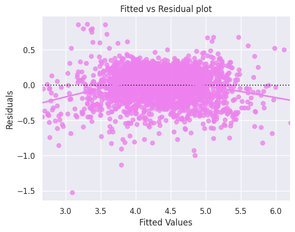

```python
sns.residplot(
    data=df_pred, x="Fitted Values", y="Residuals", color="violet", lowess=True
)
plt.xlabel("Fitted Values")
plt.ylabel("Residuals")
plt.title("Fitted vs Residual plot")
plt.show()
```

**Observations**

- Scatter plot shows the distribution of residuals and fitted values.
- **The plot doesn't follow any pattern. Assumptions about linearity and independence are satisfied.**

#### NORMALITY OF ERROR

- The shape of the histogram of residuals can give an initial idea about the normality.
- It can also be checked via a Q-Q plot of residuals. If the residuals follow a normal distribution, they will make a straight line plot, otherwise not.
- Other tests to check for normality includes the Shapiro-Wilk test.
  - Null hypothesis: Residuals are normally distributed
  - Alternate hypothesis: Residuals are not normally distributed

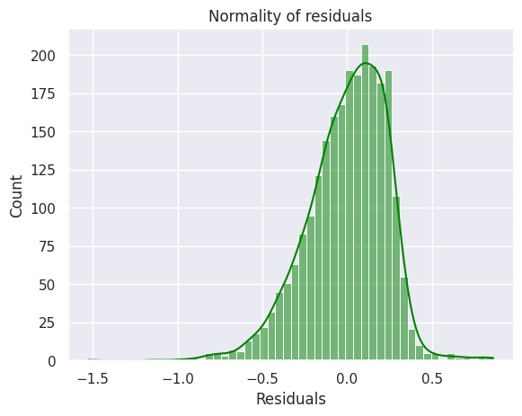

```python
sns.histplot(data=df_pred, x='Residuals', kde=True, color='green') ## Complete the code to plot the distribution of residuals
plt.title("Normality of residuals")
plt.show()
```

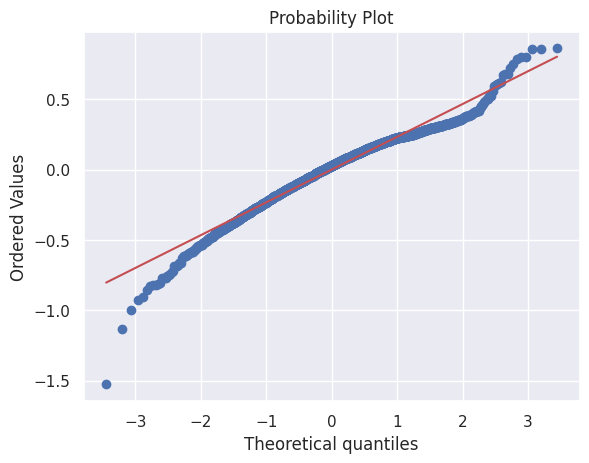

```python
import pylab
import scipy.stats as stats

stats.probplot(df_pred['Residuals'], dist="norm", plot=pylab) ## Complete the code check Q-Q plot
plt.show()
```

```python
stats.shapiro(df_pred['Residuals'])
```

```
ShapiroResult(statistic=0.9704340065495929, pvalue=6.404618530675067e-22)
```

**Observations**

- Since p-value < 0.05, the residuals are not normal as per the Shapiro-Wilk test but could be defined as normal by proximity.
- By Q-Q plot residuals show normality.
- **The assumption is satisfied**

#### TEST FOR HETEROSCEDASTICITY

- **Homoscedascity**: If the variance of the residuals is symmetrically distributed across the regression line, then the data is said to be homoscedastic.
- **Heteroscedascity**: If the variance is unequal for the residuals across the regression line, then the data is said to be heteroscedastic.
- The residual vs fitted values plot can be looked at to check for homoscedasticity. In the case of heteroscedasticity, the residuals can form an arrow shape or any other non-symmetrical shape.
- The goldfeldquandt test can also be used. If we get a p-value > 0.05 we can say that the residuals are homoscedastic. Otherwise, they are heteroscedastic.
  - Null hypothesis: Residuals are homoscedastic
  - Alternate hypothesis: Residuals have heteroscedasticity

```python
import statsmodels.stats.api as sms
from statsmodels.compat import lzip

name = ["F statistic", "p-value"]
test = sms.het_goldfeldquandt(df_pred["Residuals"], x_train6) ## Complete the code with the right train data to apply the Goldfeldquandt test
lzip(name, test)
```

```
[('F statistic', 1.0162458020411484), ('p-value', 0.39038493075871056)]
```

**Observations** Given that p-value > 0.05, we can say that the residuals are homoscedastic. **The assumption is satisfied.**

## Final Model

After adapting the model to avoid any errors and ensuring that we use only the key factors affecting the value of used price. We can build our final model

```python
olsmodel_final = sm.OLS(y_train, x_train6).fit()
print(olsmodel_final.summary())
```

```
                              OLS Regression Results
=================================================================================
Dep. Variable:     normalized_used_price   R-squared:                       0.836
Model:                               OLS   Adj. R-squared:                  0.835
Method:                    Least Squares   F-statistic:                     875.6
Date:                   Fri, 11 Oct 2024   Prob (F-statistic):               0.00
Time:                           20:34:29   Log-Likelihood:                 57.707
No. Observations:                   2417   AIC:                            -85.41
Df Residuals:                       2402   BIC:                             1.440
Df Model:                             14
Covariance Type:               nonrobust
========================================================================================
                           coef    std err          t      P>|t|      [0.025      0.975]
----------------------------------------------------------------------------------------
const                    1.4591      0.048     30.413      0.000       1.365       1.553
main_camera_mp           0.0228      0.001     16.045      0.000       0.020       0.026
selfie_camera_mp         0.0170      0.001     16.998      0.000       0.015       0.019
ram                      0.0186      0.005      4.109      0.000       0.010       0.027
weight                   0.0017   6.02e-05     28.436      0.000       0.002       0.002
days_used            -9.318e-05   2.42e-05     -3.849      0.000      -0.000   -4.57e-05
normalized_new_price     0.4180      0.011     39.050      0.000       0.397       0.439
brand_name_Honor         0.0575      0.028      2.052      0.040       0.003       0.112
brand_name_Infinix       0.1830      0.085      2.155      0.031       0.016       0.350
brand_name_Lenovo        0.0503      0.022      2.299      0.022       0.007       0.093
brand_name_Nokia         0.0807      0.031      2.608      0.009       0.020       0.141
brand_name_Sony         -0.0682      0.031     -2.222      0.026      -0.128      -0.008
brand_name_Xiaomi        0.0937      0.026      3.602      0.000       0.043       0.145
os_Others               -0.1577      0.028     -5.548      0.000      -0.213      -0.102
4g_yes                   0.0898      0.014      6.580      0.000       0.063       0.117
==============================================================================
Omnibus:                      226.072   Durbin-Watson:                   1.915
Prob(Omnibus):                  0.000   Jarque-Bera (JB):              416.351
Skew:                          -0.633   Prob(JB):                     3.89e-91
Kurtosis:                       4.590   Cond. No.                     1.31e+04
==============================================================================

Notes:
[1] Standard Errors assume that the covariance matrix of the errors is correctly specified.
[2] The condition number is large, 1.31e+04. This might indicate that there are
strong multicollinearity or other numerical problems.
```

```python
# checking model performance on train set (seen 70% data)
print("Training Performance\n")
olsmodel_final_train_perf = model_performance_regression(olsmodel_final, x_train6, y_train)
olsmodel_final_train_perf
```

```
Training Performance
```

|  | RMSE | MAE | R-squared | Adj. R-squared | MAPE |
| --- | --- | --- | --- | --- | --- |
| 0 | 0.236262 | 0.184698 | 0.836159 | 0.835136 | 4.440728 |

```python
# checking model performance on test set (seen 30% data)
print("Test Performance\n")
olsmodel_final_test_perf = model_performance_regression(olsmodel_final, x_test6, y_test) ## Complete the code to check performance on test data
olsmodel_final_test_perf
```

```
Test Performance
```

|  | RMSE | MAE | R-squared | Adj. R-squared | MAPE |
| --- | --- | --- | --- | --- | --- |
| 0 | 0.243751 | 0.188672 | 0.835271 | 0.832851 | 4.606086 |

**Observations**

## Actionable Insights and Recommendations

Recommendation:

- ReCell should focus their market strategies in the main factors attracting customers and affecting the price of the device positively
- ReCell should be focused in brands like Infinix, Xiaomi or Nokia and stay away from Sony. In these devices, 4G should be present to also affect the value of the device positively.
- Further analysis should be performed including age and income to better predict customer behaviours.
- ReCell should focus their attention in used/refurbished devices with the brand Infinix. The value of these units comes with better relation device vs price.

Code created and adapted by Roberto Torres using learning and examples shown in classes during the course.